# Assignment 1

Aleksandar Maric, Akando Räderer, Daniel Margolin

2026-03-04

## Exercise 1

### Cleaning the dataset

First we import the dataset in R and take a glimpse at the `summary()`.

```r
data <- read.csv("Assignment1.csv")
summary(data)
```

```
##        X            visits           gender              income
##  Min.   :   1   Min.   :0.00000   Length:5190        Min.   :0.0000
##  1st Qu.:1298   1st Qu.:0.07143   Class :character   1st Qu.:0.2500
##  Median :2596   Median :0.21429   Mode  :character   Median :0.5500
##  Mean   :2596   Mean   :0.23248                      Mean   :0.5832
##  3rd Qu.:3893   3rd Qu.:0.35714                      3rd Qu.:0.9000
##  Max.   :5190   Max.   :0.85714                      Max.   :1.5000
##     illness        reduced              health          private
##  Min.   :0.000   Length:5190        Min.   : 0.000   Min.   :0.0000
##  1st Qu.:0.000   Class :character   1st Qu.: 0.000   1st Qu.:0.0000
##  Median :1.000   Mode  :character   Median : 0.000   Median :0.0000
##  Mean   :1.432                      Mean   : 1.218   Mean   :0.4428
##  3rd Qu.:2.000                      3rd Qu.: 2.000   3rd Qu.:1.0000
##  Max.   :5.000                      Max.   :12.000   Max.   :1.0000
##    freepoor          freerepat           nchronic           lchronic
##  Length:5190        Length:5190        Length:5190        Length:5190
##  Class :character   Class :character   Class :character   Class :character
##  Mode  :character   Mode  :character   Mode  :character   Mode  :character
##
##
##
##   age_squared
##  Min.   :     361
##  1st Qu.:     484
##  Median :    1024
##  Mean   :   18026
##  3rd Qu.:    3844
##  Max.   :82810000
```

```r
skimr::skim(data)
```

Data summary

| Name | data |
| --- | --- |
| Number of rows | 5190 |
| Number of columns | 13 |
| _______________________ |  |
| Column type frequency: |  |
| character | 6 |
| numeric | 7 |
| ________________________ |  |
| Group variables | None |

**Variable type: character**

| skim_variable | n_missing | complete_rate | min | max | empty | n_unique | whitespace |
| --- | --- | --- | --- | --- | --- | --- | --- |
| gender | 0 | 1.0 | 4 | 6 | 0 | 2 | 0 |
| reduced | 0 | 1.0 | 1 | 13 | 0 | 16 | 0 |
| freepoor | 519 | 0.9 | 2 | 3 | 0 | 2 | 0 |
| freerepat | 0 | 1.0 | 2 | 3 | 0 | 2 | 0 |
| nchronic | 0 | 1.0 | 2 | 3 | 0 | 2 | 0 |
| lchronic | 0 | 1.0 | 2 | 3 | 0 | 2 | 0 |

**Variable type: numeric**

| skim_variable | n_missing | complete_rate | mean | sd | p0 | p25 | p50 | p75 | p100 | hist |
| --- | --- | --- | --- | --- | --- | --- | --- | --- | --- | --- |
| X | 0 | 1 | 2595.50 | 1498.37 | 1 | 1298.25 | 2595.50 | 3892.75 | 5.190e+03 | ▇▇▇▇▇ |
| visits | 0 | 1 | 0.23 | 0.17 | 0 | 0.07 | 0.21 | 0.36 | 8.600e-01 | ▇▆▅▁▁ |
| income | 0 | 1 | 0.58 | 0.37 | 0 | 0.25 | 0.55 | 0.90 | 1.500e+00 | ▇▆▅▅▂ |
| illness | 0 | 1 | 1.43 | 1.38 | 0 | 0.00 | 1.00 | 2.00 | 5.000e+00 | ▇▂▂▁▁ |
| health | 0 | 1 | 1.22 | 2.12 | 0 | 0.00 | 0.00 | 2.00 | 1.200e+01 | ▇▁▁▁▁ |
| private | 0 | 1 | 0.44 | 0.50 | 0 | 0.00 | 0.00 | 1.00 | 1.000e+00 | ▇▁▁▁▆ |
| age_squared | 0 | 1 | 18026.38 | 1149446.63 | 361 | 484.00 | 1024.00 | 3844.00 | 8.281e+07 | ▇▁▁▁▁ |

We know that the dataset contains information (5190 entries) on doctor visits in Johto with several variables. Now we handle extreme values.

At first sight we have 519 missing values for freepoor which we will remove with the assumption of them MCAR.

```r
data <- data |> filter(!is.na(freepoor))
```

After a closer look, we find that there are several entries for the `reduced` variable with $99$ which makes no sense if the question regarding this variable asks for days of reduced activity in the past two weeks. We can also observe one `age_squared` that is quite extreme ($82810000 \rightarrow \sqrt{82810000} = 9100$). This could of course be a typo for age 91, but it’s safer to remove the entry.

In the following chunk, we change the “none” entries to “$0$” and the “entire period” to “$14$”, then convert to numeric and filter for $\leq 14$. Finally, we explicitly filter out impossible values for `age_squared` by bounding the maximum realistic age (e.g., 110 years, meaning `age_square` $\leq 12100$).

```r
data <- data |>
  mutate(
    reduced = case_when(
      reduced == "none" ~ "0",
      reduced == "entire period" ~ "14",
      TRUE ~ reduced
    ),
    reduced = as.numeric(reduced)
  ) |>
  filter(reduced <= 14) |>
  filter(age_squared <= 12100)
```

### Monthly Income

To compute the average monthly income and its variance, we should first use the correct units. According to the assignment, it’s the annual income in tens of thousands of dollars. We therefore just multiply the whole column by 10’000 and divide by 12 (and create a new column):

```r
data <- data |> mutate(monthly_income = (income * 10000) / 12)
```

We then use `mean()` $\frac{1}{n}\sum_{i=1}^n X_i$ for the average monthly income and `var()` $Var(X) = \mathbb E [(X-\mathbb E[X])^2]$ for the variance (and remember that the standard deviation (`sd() = sqrt(var())`) is just its root $\sigma_X = \sqrt{Var(X)}$).

```r
mean(data$monthly_income, na.rm=TRUE)
```

```
## [1] 486.8345
```

```r
var(data$monthly_income, na.rm=TRUE)
```

```
## [1] 94990.29
```

```r
sd(data$monthly_income, na.rm=TRUE)
```

```
## [1] 308.2049
```

```r
#sqrt(variance_monthly_income)
```

#### Correlation Income vs. Health

*Ex-ante:* We assume that a higher monthly income is associated with better overall health. However, since we’re working with a GHQ score using Goldberg’s method (where a higher score = worse health), we expect to see a negative statistical correlation between the two variables.

```r
cor(data$monthly_income, data$health)
```

```
## [1] -0.08207117
```

*Ex-post:* The correlation coefficient of -0.08 indicates a statistically significant but weak negative relationship between monthly income and the GHQ health score.

## Exercise 2

### Creating relevant datasets

```r
data_private <- data |>
  select(health, monthly_income, private) |>
  mutate(
    insurance_type = factor(
      ifelse(private == 1, "private", "non-private"),
      levels = c("non-private", "private")
    )
  )

data_age <- data |>
  select(health, monthly_income, age_squared) |>
  mutate(
    age_class = factor(
      ifelse(age_squared > median(age_squared), "Above Median", "Below Median"),
      levels = c("Below Median", "Above Median")
    )
  )
```

### Generating the graphs

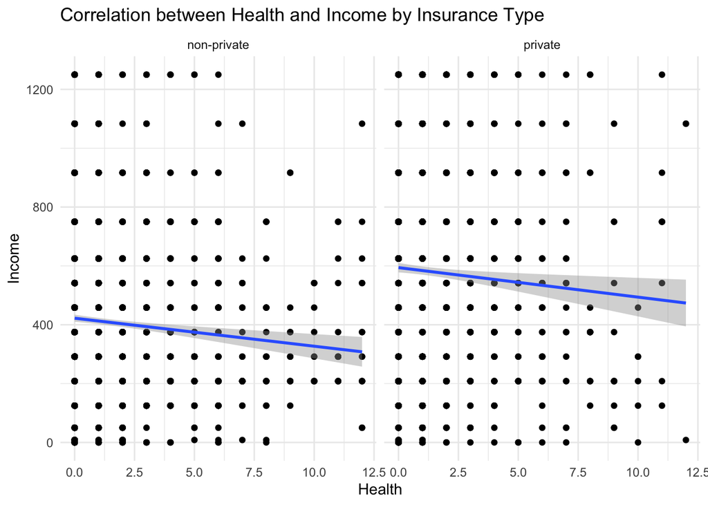

```r
ggplot(data_private, aes(x=health, y=monthly_income)) +
  geom_point() +
  geom_smooth(method = "lm") +
  facet_wrap(~ insurance_type) +
  labs(
    title = "Correlation between Health and Income by Insurance Type",
    x = "Health",
    y = "Income"
  ) +
  theme_minimal()
```

```r
# For the visual correlation
cor_by_group1 <- data_private |>
  group_by(insurance_type) |>
  summarise(correlation = cor(monthly_income, health, use = "complete.obs"))

print(cor_by_group1)
```

```
## # A tibble: 2 × 2
##   insurance_type correlation
##   <fct>                <dbl>
## 1 non-private        -0.0793
## 2 private            -0.0602
```

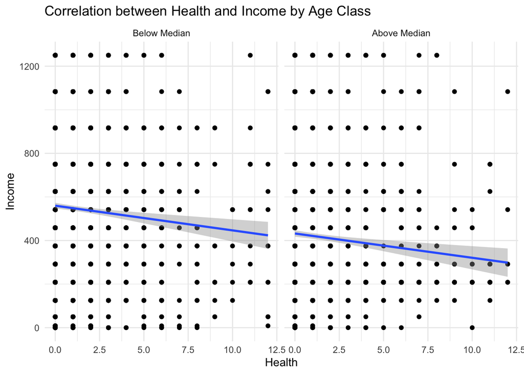

```r
ggplot(data_age, aes(x=health, y=monthly_income)) +
  geom_point() +
  geom_smooth(method = "lm") +
  facet_wrap(~ age_class) +
  labs(
    title = "Correlation between Health and Income by Age Class",
    x = "Health",
    y = "Income"
  ) +
  theme_minimal()
```

```r
cor_by_group2 <- data_age |>
  group_by(age_class) |>
  summarise(correlation = cor(monthly_income, health, use = "complete.obs"))

print(cor_by_group2)
```

```
## # A tibble: 2 × 2
##   age_class    correlation
##   <fct>              <dbl>
## 1 Below Median     -0.0792
## 2 Above Median     -0.0791
```

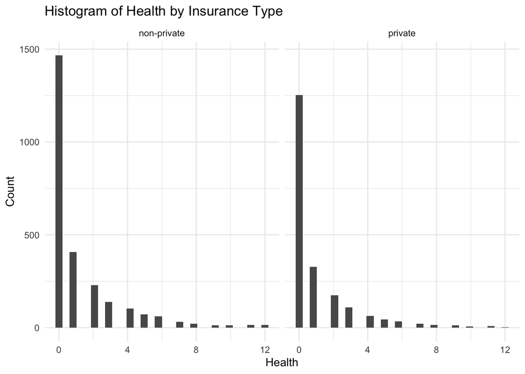

```r
ggplot(data_private, aes(x=health)) +
  geom_histogram() +
  facet_wrap(~ insurance_type) +
  labs(
    title = "Histogram of Health by Insurance Type",
    x = "Health",
    y = "Count"
  ) +
  theme_minimal()
```

### Conclusion

The correlation of these graphs are all small and negative ($\sim-0.08, \sim-0.06, \sim-0.08, \sim-0.08$). In a simple bivariate regression $r^2=R^2$. This implies that income explains less than $1\%$ of the variation in health. This suggests that income alone has very limited explanatory power for health in this sample.

In the case of the insurance types, the correlation is slightly negative for both types and the slopes are similar. The individuals with private insurance appear to have slightly better average levels of health.

The graphs by age show similar results. The negative association between income and health persists across age groups. Individuals below the median age appear to have better overall health than those above the median.

The histograms look similar and follow the same trend. The private insurance group is smaller overall, suggesting fewer privately insured individuals in the sample. The similar shapes indicate only minor differences in the distribution of health. We can draw the following conclusion:

- Income shows only a minimal correlation with health, suggesting other factors may also play a role.

Correlation implies association, not causation. This relationship might be driven by reverse causality or omitted variables like education. Cross-sectional data cannot establish a definitive causal link.